# R Visualizations

Joseph Rickert

March 22, 2016

## Visualizations in R

There are three major plotting systems in R: (1) base graphics, (2) lattice graphics and (3) ggplot2. Additionally, there is a significant amount of development work going on to allow R users to produce, Javascript plots. In this module we ill give an example of plotting histograms in all three systems and then go on to show more ggplot2 examples and finish with a Javascript based interactive plot

### R’s Three Plotting Systems

For this we will use Duncan’s famous Prestige data set that shows income, education level and a prestige score for “professional” (prof), “blue collar” (bc), and “white collar” (wc) workers/

### Base Graphics Histograms

```r
library(car)
data(Duncan)
dim(Duncan)
```

```
## [1] 45  4
```

```r
head(Duncan)
```

```
##            type income education prestige
## accountant prof     62        86       82
## pilot      prof     72        76       83
## architect  prof     75        92       90
## author     prof     55        90       76
## chemist    prof     64        86       90
## minister   prof     21        84       87
```

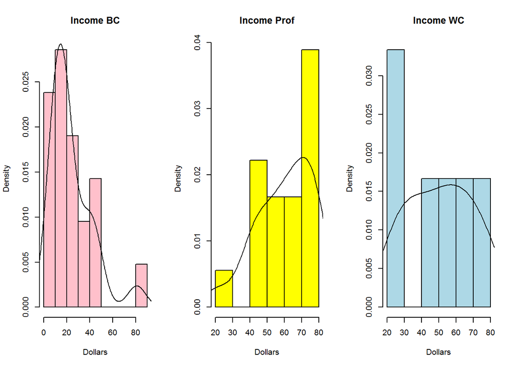

```r
# Select data using basic subsetting
inc_prof <- Duncan[Duncan$type=="prof","income"]
inc_bc <- Duncan[Duncan$type=="bc","income"]
inc_wc <- Duncan[Duncan$type=="wc","income"]

par(mfrow=c(1,3))  # set option to put 3 plots in one pane
hist(inc_bc, prob = TRUE, col = "pink", main = ("Income BC"), xlab=("Dollars"))
             lines(density(inc_bc))
hist(inc_prof, prob = TRUE, col = "yellow", main = ("Income Prof"), xlab=("Dollars"))
             lines(density(inc_prof))
hist(inc_wc, prob = TRUE, col = "light blue", main = ("Income WC"), xlab=("Dollars"))
lines(density(inc_wc))
```

```r
par(mfrow=c(1,1))
```

### Lattice (trellis) Graphics

Lattice graphics are the second major plotting system in R. Plots built with lattice have a very distinctive look, but the real value is the ease of making trellis plots - graphs that display a variable conditioned on an other variable. Some useful websites are: http://www.statmethods.net/advgraphs/trellis.html http://user2007.org/program/presentations/sarkar.pdf

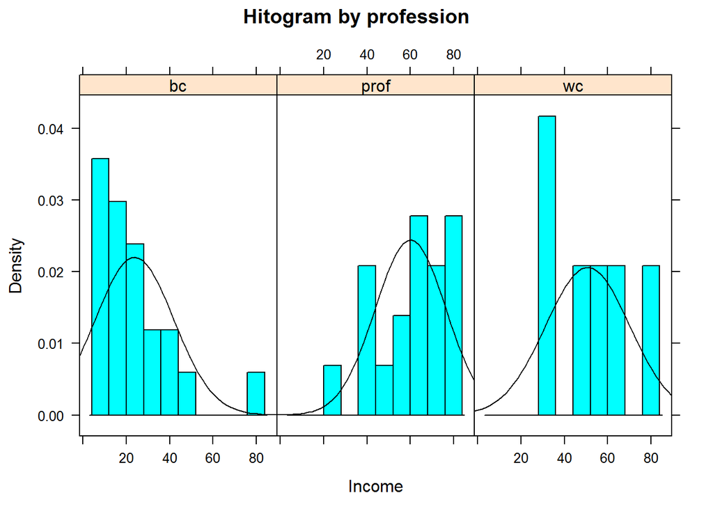

```r
library(lattice)
histogram( ~ income | type,
           data = Duncan,
           nint=10,
           xlab = "Income",
           main= "Hitogram by profession",
           type = "density",
           panel = function(x, ...) {
             panel.histogram(x, ...)
             panel.mathdensity(dmath = dnorm, col = "black",
                               args = list(mean=mean(x),sd=sd(x)))
           } )
```

### ggplot2 Graphics

ggplot is the third major plotting system for R. It is based on Leland Wilkinson’s grammar of graphics. Plots are built in layers. Some useful websites are: http://www.cs.uic.edu/~wilkinson/TheGrammarOfGraphics/GOG.html http://ggplot2.org/ http://docs.ggplot2.org/current/ http://www.cookbook-r.com/Graphs/ http://www.rstudio.com/wp-content/uploads/2015/12/ggplot2-cheatsheet-2.0.pdf

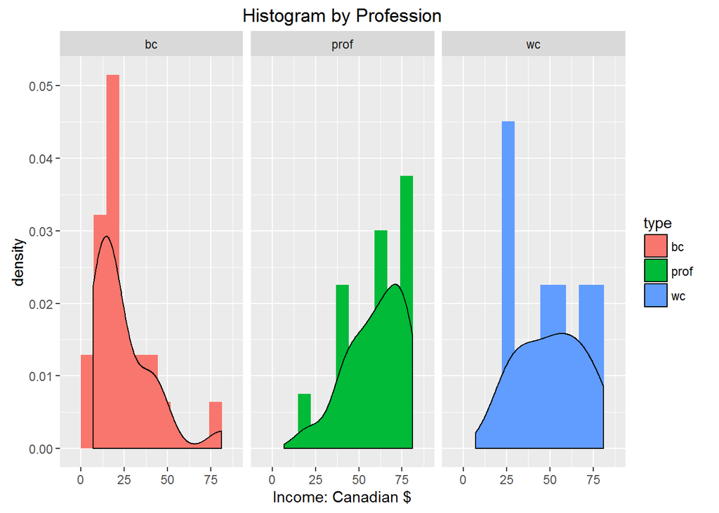

```r
library(ggplot2)
p1 <- ggplot(Duncan,aes(income,..density.., fill=type))
p1 + geom_histogram(bins=10) +
     facet_grid(. ~ type) +
     geom_density() +
     xlab("Income: Canadian $") +
     ggtitle("Histogram by Profession")
```

### More ggplot 2 visualizations We will use the diamonds data set that comes with the ggplot2 package.

```r
library(dplyr)
data(diamonds)
head(diamonds)
```

```
## Source: local data frame [6 x 10]
##
##   carat       cut  color clarity depth table price     x     y     z
##   (dbl)    (fctr) (fctr)  (fctr) (dbl) (dbl) (int) (dbl) (dbl) (dbl)
## 1  0.23     Ideal      E     SI2  61.5    55   326  3.95  3.98  2.43
## 2  0.21   Premium      E     SI1  59.8    61   326  3.89  3.84  2.31
## 3  0.23      Good      E     VS1  56.9    65   327  4.05  4.07  2.31
## 4  0.29   Premium      I     VS2  62.4    58   334  4.20  4.23  2.63
## 5  0.31      Good      J     SI2  63.3    58   335  4.34  4.35  2.75
## 6  0.24 Very Good      J    VVS2  62.8    57   336  3.94  3.96  2.48
```

```r
dim(diamonds)
```

```
## [1] 53940    10
```

```r
set.seed(123)
dsmall <- sample_n(diamonds,5000)
```

### Scatter plots

http://docs.ggplot2.org/current/geom_path.html plot price by caret and color with cut

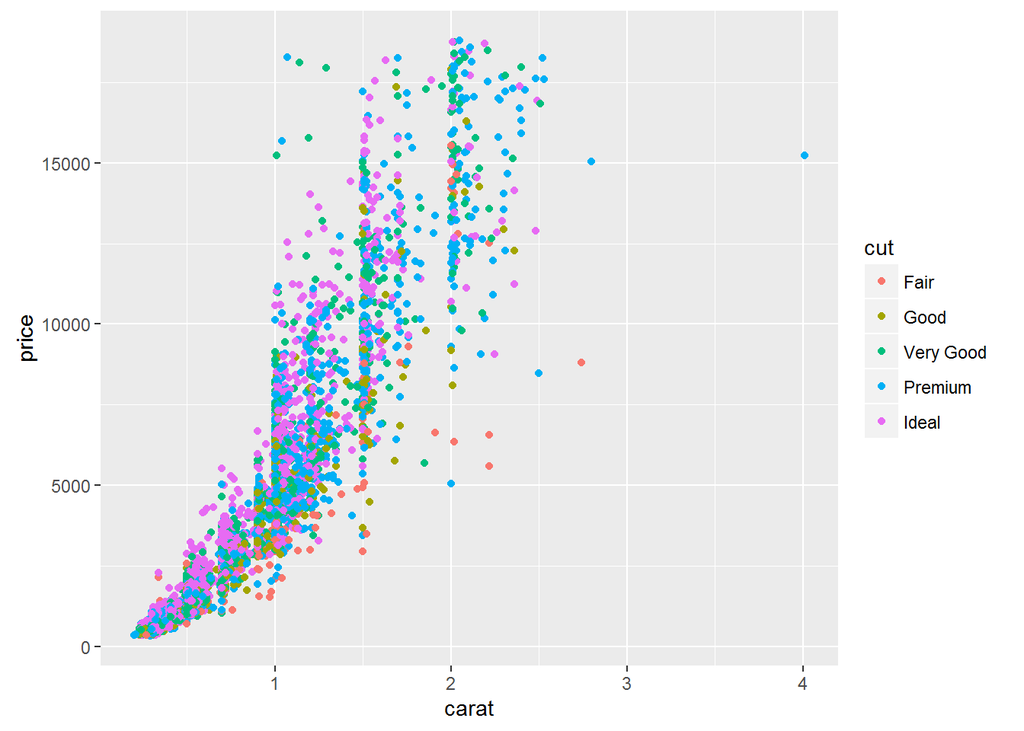

```r
p1 <- ggplot(dsmall,aes(carat,price,color=cut))
p1 + geom_point()
```

Break out by clarity

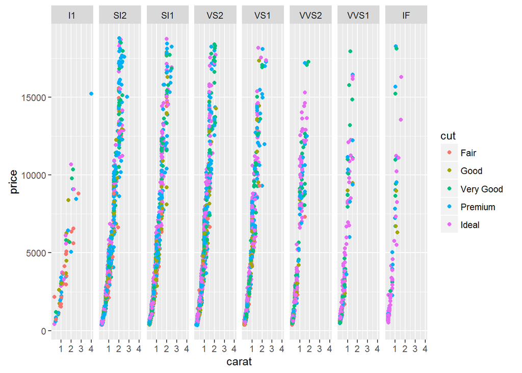

```r
p1 + geom_point() + facet_grid(. ~ clarity)
```

### Histograms http://docs.ggplot2.org/current/geom_histogram.html

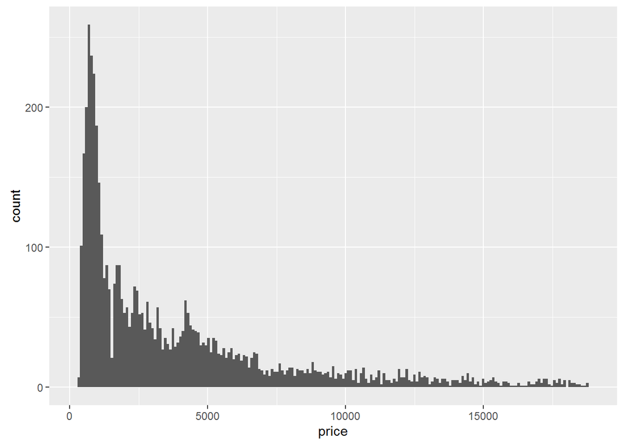

```r
p2 <- ggplot(dsmall, aes(x = price))
p2 + geom_histogram(bins=200)
```

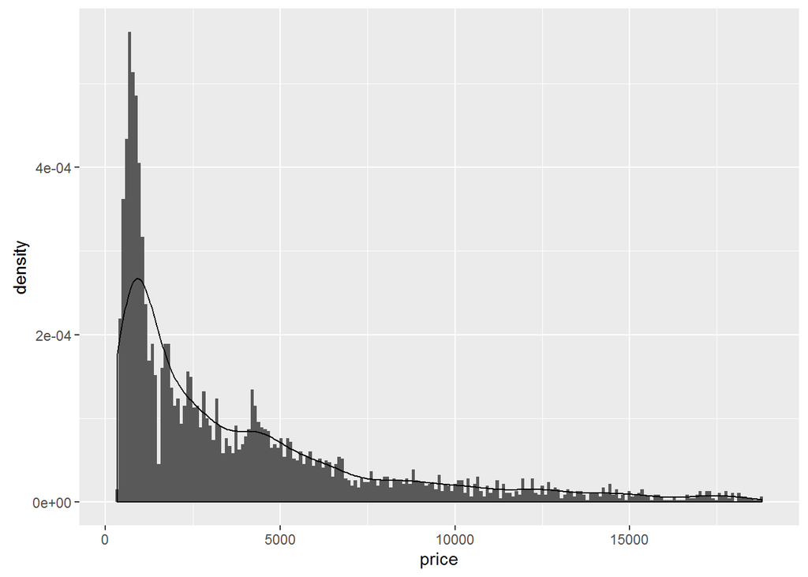

```r
p2 <- ggplot(dsmall, aes(x = price, ..density..))
p2 + geom_histogram(bins=200) + geom_density()
```

### Boxplots

http://docs.ggplot2.org/0.9.3.1/geom_boxplot.html

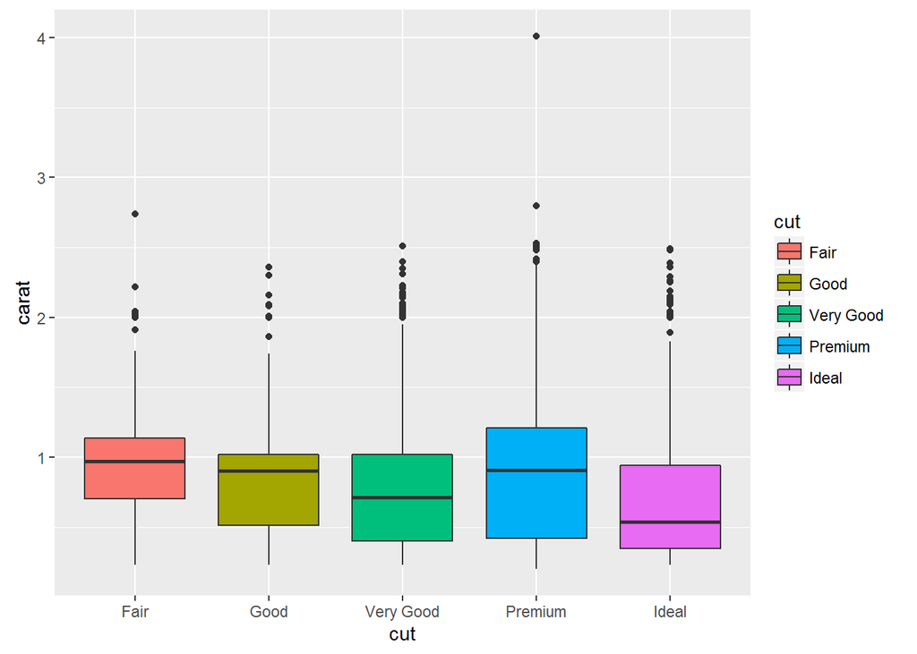

```r
p3 <- ggplot(dsmall, aes(cut,carat,fill=cut))
p3 + geom_boxplot()
```

### Scatter plot with statistical smoothing

http://docs.ggplot2.org/current/geom_smooth.html

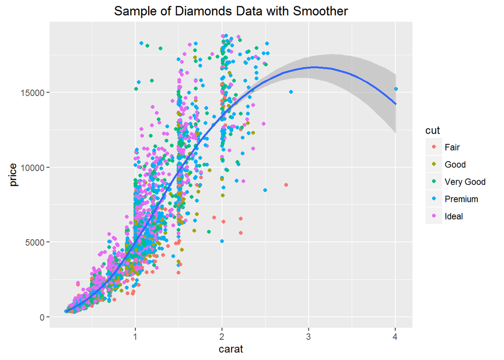

```r
p4 <- ggplot(data = dsmall, aes(carat, price))
p4 +  geom_point(aes(colour=cut)) +
      geom_smooth(method="loess") +
      ggtitle("Sample of Diamonds Data with Smoother")
```

### Plotting the Nile Overflow Data

```r
# library(ggplot2)            # for plotting functions
# library(car)                # for the recode function, rc
library(reshape2)           # for melt function to build long form data frame
library(pracma)             # for Nile river data
data(nile)
head(nile)
```

```
##   Year  Jan  Feb  Mar Apr May  Jun  Jul   Aug   Sep  Oct  Nov  Dec
## 1 1871 2606 1992 1485 933 731  760 2475  8960  9953 6571 3522 2419
## 2 1872 1672 1033  728 605 560  879 3121  8811 10532 7952 4976 3102
## 3 1873 2187 1851 1235 756 556 1392 2296  7093  8410 5675 3070 2049
## 4 1874 1340  847  664 516 466  964 3061 10790 11805 8064 4282 2904
## 5 1875 2210 1686 1060 771 638  698 2396  9259 10455 7691 4436 2830
## 6 1876 2116 1791 1441 945 724  887 3106  8811 11072 6757 3788 2523
```

```r
# Many data frames arenaturally in “wide” form. To plot this data with ggplot2 te data must be transformed into “long” form.
nile_dat <- melt(nile,idvar="Year",measure.vars=month.abb,variable.name="Month",value.name="Obs")
nile_dat_long <- nile_dat[with(nile_dat,order(Year,Month)),]         # sort
head(nile_dat_long)
```

```
##     Year Month  Obs
## 1   1871   Jan 2606
## 115 1871   Feb 1992
## 229 1871   Mar 1485
## 343 1871   Apr  933
## 457 1871   May  731
## 571 1871   Jun  760
```

```r
# Make a date variable
nile_dat_long$Date <- paste(with(nile_dat_long,Date<- paste(Month,"-","15","-",as.character(Year),sep="")))
nile_dat_long$Date <- as.Date(nile_dat_long$Date,format="%b-%d-%Y")

head(nile_dat_long)
```

```
##     Year Month  Obs       Date
## 1   1871   Jan 2606 1871-01-15
## 115 1871   Feb 1992 1871-02-15
## 229 1871   Mar 1485 1871-03-15
## 343 1871   Apr  933 1871-04-15
## 457 1871   May  731 1871-05-15
## 571 1871   Jun  760 1871-06-15
```

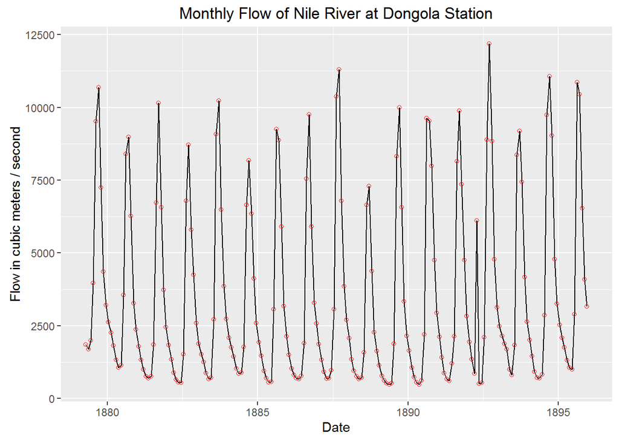

```r
# Plot the time series
p <- ggplot(nile_dat_long[100:300,],aes(x=Date,y=Obs))
p + geom_line() + geom_point(shape=1,col="red") +
  ylab("Flow in cubic meters / second") +
  ggtitle("Monthly Flow of Nile River at Dongola Station")
```

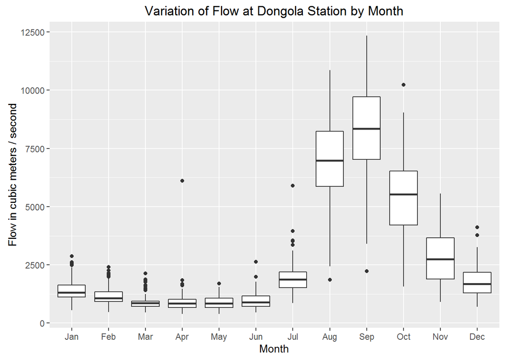

```r
# Boxplots of monthly flows
b <- ggplot(nile_dat_long,aes(factor(Month),Obs))
b + geom_boxplot() +
  xlab("Month") +
  ylab("Flow in cubic meters / second") +
  ggtitle("Variation of Flow at Dongola Station by Month")
```

### Create an interactive graph with a Javascript library

```r
library(xts)
```

```r
library(dygraphs)
# Make into a time series object
nile_ts <- xts(nile_dat_long$Obs,
               order.by=nile_dat_long$Date,
               frequency=12,start=c(1871,1))

# Plot wit htmlwidget dygraph
dygraph(nile_ts,ylab="cubic m / s",
        main="Nile Monthly Flow Data") %>%
  dySeries("V1",label="Flow") %>%
  dyRangeSelector(dateWindow = c("1871-01-01","1984-12-01"))
```

[interactive chart not shown]